# 社會科學統計方法

蔡佳泓

4/24/2018

# 1 課程目標

本週上課將介紹`R`的`dplyr`的套件中的指令，包括`select`、`filter`、 `mutate`等函數，協助研究者整理資料，並且轉置資料。例如：

```r
library(dplyr)
students<-read.table('studentsfull.txt', sep='', header=TRUE)
students.part<-mutate(students, sex=as.numeric(Gender)-1)
students.part
```

```
##          ID     Name Department Score Gender sex
## 1  10322011    Ariel  Aerospace    78      F   0
## 2  10325023    Becky    Physics    86      F   0
## 3  10430101     Carl Journalism    69      M   1
## 4  10401032  Dimitri    English    83      M   1
## 5  10307120  Enrique  Chemistry    80      M   1
## 6  10207005 Fernando  Chemistry    66      M   1
## 7  10305019   George  Mechanics    75      F   0
## 8  10305022   Howell  Mechanics    81      M   1
## 9  10305029      Ian  Mechanics    60      M   1
## 10 10305031    Julio  Mechanics    89      M   1
## 11 10322014    Kaori  Aerospace    82      F   0
## 12 10425026     Luke    Physics    88      M   1
## 13 10401022   Miguel    English    92      M   1
## 14 10501006      Neo    English    77      M   1
## 15 10321010   Olivia  Economics    85      F   0
## 16 10321011    Peter  Economics    88      M   1
## 17 10405017     Qing  Mechanics    88      F   0
## 18 10422007    Ricky  Aerospace    91      M   1
## 19 10422008    Seiko  Aerospace    80      F   0
## 20 10430005  Terresa Journalism    62      F   0
## 21 10530009     Usla Journalism    87      F   0
## 22 10421001   Vivian  Economics    70      F   0
## 23 10307018    Wendy  Chemistry    85      F   0
## 24 10425003     Xing    Physics    93      M   1
## 25 10221030     Yoko  Economics    66      F   0
## 26 10430015      Zoe Journalism    92      F   0
```

# 2 資料的型態

之前我們學習`R`的基礎指令，而`dplyr`提供許多指令幫我們整理資料。Hadley Wickman 發展了`plyr`套件，然後又發展`dplyr`套件。為了節省時間，我們直接討論`dplyr`的幾個實用的函數。

## 2.1 tibble

在下載`dplyr`套件之後，請嘗試這個指令：

```r
library(dplyr)
tibble(
  s=c("all","at","air","age", "angle"),
  x = 1:5,
  y = 1,
  z = x  + y,
  )
```

```
## # A tibble: 5 x 4
##   s         x     y     z
##   <chr> <int> <dbl> <dbl>
## 1 all       1    1.    2.
## 2 at        2    1.    3.
## 3 air       3    1.    4.
## 4 age       4    1.    5.
## 5 angle     5    1.    6.
```

或者是：

```r
data_frame(s=c("all","at","air","age", "angle"), x = 1:5, y = 1, z = x  + y)
```

```
## # A tibble: 5 x 4
##   s         x     y     z
##   <chr> <int> <dbl> <dbl>
## 1 all       1    1.    2.
## 2 at        2    1.    3.
## 3 air       3    1.    4.
## 4 age       4    1.    5.
## 5 angle     5    1.    6.
```

tibble是一個新的資料型態，比資料框(data.frame)多了變數的資訊，而且會顯示前面十個觀察值的資訊，以及螢幕剛好足夠容納的下的變數。例如打開pp0797B2.sav這個檔案，但是把它視為tibble而不是data.frame：

```r
library(foreign)
setwd("~/Library/Mobile Documents/com~apple~CloudDocs/eastasia")
pp0797b2<-read.spss('PP0797B2.sav', to.data.frame=TRUE)
tibble_pp0797b2<-as_tibble(pp0797b2)
tibble_pp0797b2
```

```
## # A tibble: 2,058 x 24
##    Q1     Q2     Q3     Q4     Q5    Q6    Q7    Q8    Q9    Q10   partyid
##    <fct>  <fct>  <fct>  <fct>  <fct> <fct> <fct> <fct> <fct> <fct> <fct>
##  1 很難說 同意   不同意 同意   同意  不同意… 同意  不相信… 不同意… 不同意… 國民黨
##  2 非常不同意… 非常同意… 不同意 同意   很難說… 不同意… 不同意… 不相信… 不同意… 不同意… 中立及看情形…
##  3 非常不同意… 非常同意… 非常不同意… 非常同意… 同意  非常同意… 不同意… 不相信… 不同意… 不同意… 中立及看情形…
##  4 同意   同意   不同意 同意   不同意… 非常不同… 不同意… 很難說… 不同意… 非常同意… 民進黨
##  5 非常不同意… 同意   不同意 不同意 不同意… 不同意… 同意  不相信… 同意  非常不同… 國民黨
##  6 不同意 不同意 同意   同意   同意  同意  同意  不相信… 不同意… 非常同意… 中立及看情形…
##  7 非常不同意… 同意   不同意 不同意 不同意… 不同意… 非常同意… 非常不相… 不同意… 非常同意… 中立及看情形…
##  8 非常不同意… 非常同意… 非常不同意… 非常同意… 不同意… 不同意… 同意  非常相信… 不同意… 不同意… 民進黨
##  9 同意   非常不同意… 非常同意… 不同意 非常不同… 不同意… 非常同意… 相信  不同意… 非常同意… 民進黨
## 10 不同意 不同意 不同意 同意   不同意… 非常不同… 同意  不相信… 不同意… 不同意… 民進黨
## # ... with 2,048 more rows, and 13 more variables: PARTY <fct>,
## #   tondu <fct>, ethnic <fct>, age <fct>, edu <fct>, sengiF <fct>,
## #   sengiM <fct>, CAREER <fct>, CAREER8 <fct>, TOWNID <dbl>, arear <fct>,
## #   sex <fct>, w <dbl>
```

可以看出tibble比較適用於大量的資料，讓資料分析更加容易。  
也可以用print功能，決定輸出幾個觀察值以及決定螢幕寬度。

```r
tibble_pp0797b2 %>%
  print(n=5, width=100)
```

```
## # A tibble: 2,058 x 24
##   Q1     Q2     Q3     Q4     Q5     Q6    Q7    Q8    Q9    Q10   partyid
##   <fct>  <fct>  <fct>  <fct>  <fct>  <fct> <fct> <fct> <fct> <fct> <fct>
## 1 很難說 同意   不同意 同意   同意   不同意… 同意  不相信… 不同意… 不同意… 國民黨
## 2 非常不同意… 非常同意… 不同意 同意   很難說 不同意… 不同意… 不相信… 不同意… 不同意… 中立及看情形…
## 3 非常不同意… 非常同意… 非常不同意… 非常同意… 同意   非常同意… 不同意… 不相信… 不同意… 不同意… 中立及看情形…
## 4 同意   同意   不同意 同意   不同意 非常不同… 不同意… 很難說… 不同意… 非常同意… 民進黨
## 5 非常不同意… 同意   不同意 不同意 不同意 不同意… 同意  不相信… 同意  非常不同… 國民黨
##   PARTY  tondu    ethnic
##   <fct>  <fct>    <fct>
## 1 偏國民黨… 維持現狀，以後… 都是
## 2 中立無反應… 維持現狀，看情… 台灣人
## 3 中立無反應… 永遠維持現狀… 都是
## 4 普通支持民… 維持現狀，看情… 台灣人
## 5 非常支持國… 維持現狀，以後… 都是
## # ... with 2,053 more rows, and 10 more variables: age <fct>, edu <fct>,
## #   sengiF <fct>, sengiM <fct>, CAREER <fct>, CAREER8 <fct>, TOWNID <dbl>,
## #   arear <fct>, sex <fct>, w <dbl>
```

而tibble格式的資料子集合可以是該變數的格式，也可以是資料框，可以用參數drop加以控制。例如：

```r
class(tibble_pp0797b2[,1])
```

```
## [1] "tbl_df"     "tbl"        "data.frame"
```

```r
class(tibble_pp0797b2[,1, drop=TRUE])
```

```
## [1] "factor"
```

### 2.1.1 簡潔數據(tidy dataset)

那麼，tibble的用處是什麼？tibble 來自於Hadley Wickham 發展的簡潔數據(tidy dataset)概念，簡潔數據的目標是讓每一個變數都有一個欄位（每一欄都是一個變數），而且每一筆觀察值都有一列，而且每一個值都有一儲存格（也就是每一個儲存格只有一個值，沒有例如$a/b$是由兩個值所構成）。詳見Garrett Grolemund & Hadley Wicham (http://r4ds.had.co.nz/index.html)。 tidy dataset也希望資料在同一個表，而非來自於不同的表。  
雖然以下的指令適用於資料框以及整潔數據，但是整潔數據方便大數據分析。例如我們想要pp0797b2這筆資料加權之後的性別統計：

```r
tibble_pp0797b2 %>%
  count(sex, wt=w)
```

```
## # A tibble: 2 x 2
##   sex       n
##   <fct> <dbl>
## 1 男性  1031.
## 2 女性  1027.
```

Hadley Wickham也是`ggplot2`的作者，因此tibble資料適合於`ggplot2`的視覺化，例如我們想呈現性別的分佈，不一定用得到tibble：

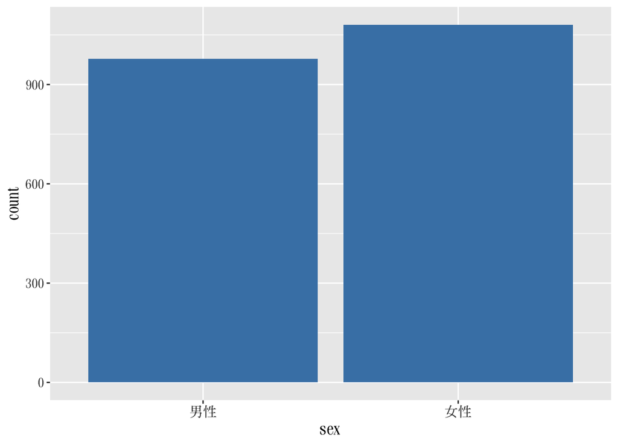

```r
library(ggplot2)
ggplot(tibble_pp0797b2, aes(x=sex)) +
  geom_bar(stat='count', fill='steelblue') +
  theme(text=element_text(family="HanWangMingBold", size=14))
```

但是要呈現兩個變數之間的相關程度（也就是聯合機率的次數），我們需要計算兩個變數的每一個類別的交叉，然後可以更容易使用ggplot2。以性別與首先計算性別類別下的民族認同（台灣人、中國人、都是、無反應），存成tibble格式的資料：

```r
df.ethnic<-tibble_pp0797b2 %>%
      group_by(sex) %>%
      count(ethnic)
df.ethnic
```

```
## # A tibble: 8 x 3
## # Groups:   sex [2]
##   sex   ethnic     n
##   <fct> <fct>  <int>
## 1 男性  台灣人   379
## 2 男性  都是     469
## 3 男性  中國人    63
## 4 男性  無反應    66
## 5 女性  台灣人   377
## 6 女性  都是     574
## 7 女性  中國人    68
## 8 女性  無反應    62
```

上述指令中的%>%被稱為pipeline，有點像是兩行指令之間的連結，讓語法看起來更優雅。  
接下來用tibble格式的df.ethnic 畫直方圖：

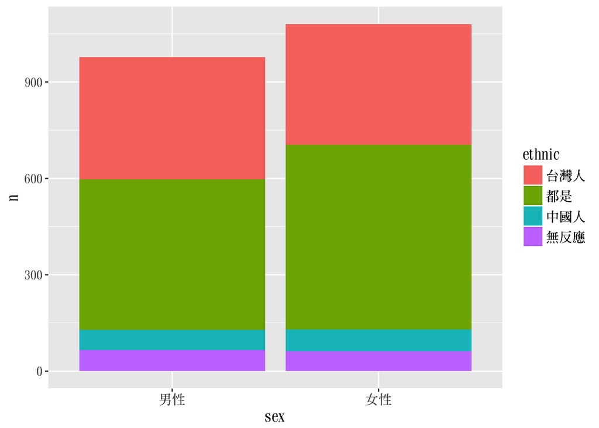

```r
g<-ggplot(df.ethnic, aes(sex, n, fill=ethnic)) +
  geom_bar(stat='identity') +
  theme(text=element_text(family="HanWangMingBold", size=14))
g
```

由此可以看出，tibble資料以及`dplyr`的指令可以直覺式地處理資料。

# 3 非摘要式指令

`dplyr`指令可以產生新的變數，也可以產生統計的結果。首先介紹轉換資料但是不產生統計摘要（例如平均值、最小值、最大值等等）結果的指令。

## 3.1 挑選特定欄位(select)

在一個二維的資料型態，假設我們想留下部分欄位的資料，捨棄其他欄位，可以用`select`這個函數。例如：

```r
library(dplyr)
dt <- tibble(
  s=c("B", "B", "A","B","A","C", "B", "B","B", "B", "A","B","A","C", "B", "B"),
  x = 1:16,
  y = 1,
  z = x  + 2*y,
  )
dt %>% select(z, s)
```

```
## # A tibble: 16 x 2
##        z s
##    <dbl> <chr>
##  1    3. B
##  2    4. B
##  3    5. A
##  4    6. B
##  5    7. A
##  6    8. C
##  7    9. B
##  8   10. B
##  9   11. B
## 10   12. B
## 11   13. A
## 12   14. B
## 13   15. A
## 14   16. C
## 15   17. B
## 16   18. B
```

## 3.2 過濾(filter)

`filter`可以篩選符合條件的變數的觀察值，篩選的變數可以超過一個，例如：

```r
tibble_pp0797b2.filter<-filter(tibble_pp0797b2, sex=="男性", TOWNID>6300)
tibble_pp0797b2.filter
```

```
## # A tibble: 130 x 24
##    Q1     Q2     Q3     Q4     Q5    Q6    Q7    Q8    Q9    Q10   partyid
##    <fct>  <fct>  <fct>  <fct>  <fct> <fct> <fct> <fct> <fct> <fct> <fct>
##  1 非常不同意… 非常同意… 不同意 同意   很難說… 不同意… 不同意… 不相信… 不同意… 不同意… 中立及看情形…
##  2 非常不同意… 非常同意… 非常不同意… 非常同意… 同意  非常同意… 不同意… 不相信… 不同意… 不同意… 中立及看情形…
##  3 非常不同意… 同意   不同意 同意   非常同意… 非常同意… 同意  非常不相… 不同意… 同意  中立及看情形…
##  4 非常不同意… 很難說 很難說 很難說 不同意… 不同意… 同意  相信  同意  不同意… 民進黨
##  5 非常同意… 非常同意… 不同意 同意   同意  同意  不同意… 非常不相… 非常不同… 非常不同… 國民黨
##  6 不同意 同意   不同意 同意   同意  同意  同意  不相信… 不同意… 不同意… 國民黨
##  7 同意   非常同意… 同意   非常同意… 不同意… 非常不同… 同意  不相信… 同意  非常不同… 民進黨
##  8 同意   非常同意… 非常不同意… 同意   非常同意… 非常同意… 同意  非常不相… 非常不同… 不同意… 中立及看情形…
##  9 很難說 拒答   同意   拒答   同意  同意  不同意… 很難說… 很難說… 不同意… 中立及看情形…
## 10 同意   同意   不同意 不同意 非常同意… 同意  同意  不相信… 不同意… 同意  國民黨
## # ... with 120 more rows, and 13 more variables: PARTY <fct>, tondu <fct>,
## #   ethnic <fct>, age <fct>, edu <fct>, sengiF <fct>, sengiM <fct>,
## #   CAREER <fct>, CAREER8 <fct>, TOWNID <dbl>, arear <fct>, sex <fct>,
## #   w <dbl>
```

可以看出，類別變數或者是數字變數都可以篩選觀察值。

## 3.3 創造新變數(mutate)

我們可以直接在資料中創造一個新變數，不需要再用錢字符號（$），並且轉換資料型態，例如：

```r
dt_mutate <- mutate(dt, S=as.factor(s), X=x*100)
dt_mutate <- mutate(dt_mutate, sn=as.numeric(S))
dt_mutate
```

```
## # A tibble: 16 x 7
##    s         x     y     z S         X    sn
##    <chr> <int> <dbl> <dbl> <fct> <dbl> <dbl>
##  1 B         1    1.    3. B      100.    2.
##  2 B         2    1.    4. B      200.    2.
##  3 A         3    1.    5. A      300.    1.
##  4 B         4    1.    6. B      400.    2.
##  5 A         5    1.    7. A      500.    1.
##  6 C         6    1.    8. C      600.    3.
##  7 B         7    1.    9. B      700.    2.
##  8 B         8    1.   10. B      800.    2.
##  9 B         9    1.   11. B      900.    2.
## 10 B        10    1.   12. B     1000.    2.
## 11 A        11    1.   13. A     1100.    1.
## 12 B        12    1.   14. B     1200.    2.
## 13 A        13    1.   15. A     1300.    1.
## 14 C        14    1.   16. C     1400.    3.
## 15 B        15    1.   17. B     1500.    2.
## 16 B        16    1.   18. B     1600.    2.
```

## 3.4 排序(arrange)

我們可以根據某一個或者一個以上的變數遞增或是遞減排序資料，例如：

```r
dt_arrange = arrange(dt, s, desc(z))
dt_arrange
```

```
## # A tibble: 16 x 4
##    s         x     y     z
##    <chr> <int> <dbl> <dbl>
##  1 A        13    1.   15.
##  2 A        11    1.   13.
##  3 A         5    1.    7.
##  4 A         3    1.    5.
##  5 B        16    1.   18.
##  6 B        15    1.   17.
##  7 B        12    1.   14.
##  8 B        10    1.   12.
##  9 B         9    1.   11.
## 10 B         8    1.   10.
## 11 B         7    1.    9.
## 12 B         4    1.    6.
## 13 B         2    1.    4.
## 14 B         1    1.    3.
## 15 C        14    1.   16.
## 16 C         6    1.    8.
```

# 4 摘要式指令

## 4.1 摘要(summarize)

我們可以直接輸出某一個變數的統計結果：

```r
summarize(dt, mean(x))
```

```
## # A tibble: 1 x 1
##   `mean(x)`
##       <dbl>
## 1      8.50
```

或者是轉成另一個變數，方便後續的分析，但是`dplyr`會存成一個tibble資料，所以需要再取出：

```r
dt.sze=summarize(dt, x.avg=mean(x), z.avg=mean(z))
dt.sze[,1]
```

```
## # A tibble: 1 x 1
##   x.avg
##   <dbl>
## 1  8.50
```

```r
dt.sze[,2]
```

```
## # A tibble: 1 x 1
##   z.avg
##   <dbl>
## 1  10.5
```

`summarize`可以計算的統計有：  
- mean，平均值 - median，中位數 - sum，總數 - min，最小值 - max，最大值 - n()，個數，也就是資料筆數 - n_distinct，類別的個數 （請見DSC2014tutorial）  
例如我們想要知道`mtcars`這筆資料中cyl的個數、平均數跟類別的數目：

```r
mtcars_n<-summarize(mtcars, n(), mean(cyl), n_distinct(cyl))
```

## 4.2 資料彙總(group_by)

我們可以根據資料內的類別變數對另一個變數進行統計，例如計算平均值，使用`group_by()`這個函數：

```r
summarize(group_by(dt, s),  mean(z))
```

```
## # A tibble: 3 x 2
##   s     `mean(z)`
##   <chr>     <dbl>
## 1 A          10.0
## 2 B          10.4
## 3 C          12.0
```

如果資料內有遺漏值，可以設定`na.rm`這個參數為真，去除遺漏值，再進行統計，例如以flights這筆資料為例，根據tailnum也就是班機號碼，彙總計算班機次數以及距離：

```r
library(nycflights13)
by_tailnum <- group_by(flights, tailnum)
delay <- summarise(by_tailnum,
  count = n(),
  dist = mean(distance, na.rm = TRUE))
delay
```

```
## # A tibble: 4,044 x 3
##    tailnum count  dist
##    <chr>   <int> <dbl>
##  1 D942DN      4  854.
##  2 N0EGMQ    371  676.
##  3 N10156    153  758.
##  4 N102UW     48  536.
##  5 N103US     46  535.
##  6 N104UW     47  535.
##  7 N10575    289  520.
##  8 N105UW     45  525.
##  9 N107US     41  529.
## 10 N108UW     60  534.
## # ... with 4,034 more rows
```

或者是（參考：https://dplyr.tidyverse.org/articles/dplyr.html ）：

```r
flights %>% group_by(tailnum) %>%
  summarize(count=n(), avgdist=mean(distance, na.rm=TRUE))
```

```
## # A tibble: 4,044 x 3
##    tailnum count avgdist
##    <chr>   <int>   <dbl>
##  1 D942DN      4    854.
##  2 N0EGMQ    371    676.
##  3 N10156    153    758.
##  4 N102UW     48    536.
##  5 N103US     46    535.
##  6 N104UW     47    535.
##  7 N10575    289    520.
##  8 N105UW     45    525.
##  9 N107US     41    529.
## 10 N108UW     60    534.
## # ... with 4,034 more rows
```

以上的說明希望大家活用`dplyr`，進行統計，並且結合資料視覺化。

# 5 資料的寬表與長表(reshape2)

`dplyr`提供了許多轉換資料以及彙總計算的功能，而針對資料的轉換，`reshape2`套件有很大的幫助。`reshape2`也是由 Hadley Wickham所寫，該套件裡最重要的兩個函數便是 melt() 與 dcast()，如同字面上的意思，melt 是熔化的意思，也就是將資料由多變數熔成較少變數且較長的資料，可以想像資料變長；cast 是鑄造的意思，也就是將資料由較少變數鑄造成較多變數且較寬的資料，可以想像資料變短。cast 有分 dcast 與 acast，只差在要輸出的形式是 data.frame 或是 array。（以上文字參考：https://blog.stranity.com.tw/2016/12/12/r語言reshape2套件/ ）

## 5.1 寬表(dcast)

將資料由少變數變形為較寬的資料，在過程中可以加上函數。例如有一筆資料表示銀行的房貸金額，我們先讀取資料，過程中擷取年份與月份：

```r
library(DSC2014Tutorial)
ETL_file("cl_info_other.csv")
```

```
## [1] "/Library/Frameworks/R.framework/Versions/3.4/Resources/library/DSC2014Tutorial/ETL/cl_info_other_unix.csv"
```

```r
bank.info = read.table(file=ETL_file("cl_info_other.csv"),sep=",",stringsAsFactors=F,header=T)
bank.part=mutate(bank.info,
                 bank_code = as.factor(bank_code),
                 etl_dt = substr(etl_dt, 1, 7))

bank.part=mutate(bank.part, yearmonth=format(etl_dt, format='%Y-%m'))
head(bank.part)
```

```
##    etl_dt  bank_code             data_dt                  bank_nm
## 1 2013-11 020        2006-01-01 00:00:00         日商瑞穗實業銀行
## 2 2013-11 N000       2006-01-01 00:00:00 台北縣淡水第一信用合作社
## 3 2013-11 809        2006-01-01 00:00:00             萬泰商業銀行
## 4 2013-11 146        2006-01-01 00:00:00     台中市第二信用合作社
## 5 2013-11 115        2006-01-01 00:00:00     基隆市第二信用合作社
## 6 2013-11 N005       2006-01-01 00:00:00       高雄第三信用合作社
##   mortgage_cnt mortgage_bal decorator_hse_cnt decorator_hse_bal ln_car_cnt
## 1            0   0.0000e+00                 0        0.0000e+00          0
## 2         9924   1.6873e+10               173        1.8300e+08          2
## 3         4051   5.6240e+09              1329        1.4710e+09       3128
## 4        11167   1.8949e+10               118        9.7000e+07         11
## 5         1551   3.7730e+09               336        4.7000e+08        178
## 6         1903   2.4760e+09              7828        1.1257e+10          0
##   ln_car_bal ln_worker_cnt ln_worker_bal other_cl_cnt other_cl_bal
## 1   0.00e+00             0      0.00e+00            0   0.0000e+00
## 2   1.00e+06           953      3.72e+08         1101   3.0900e+08
## 3   9.26e+08             0      0.00e+00      1697098   7.6111e+10
## 4   0.00e+00             0      0.00e+00         1027   3.9900e+08
## 5   4.70e+07             0      0.00e+00         2295   5.1500e+08
## 6   0.00e+00           984      5.80e+08         2866   9.4600e+08
##   yearmonth
## 1   2013-11
## 2   2013-11
## 3   2013-11
## 4   2013-11
## 5   2013-11
## 6   2013-11
```

（指令參考：`DSC2014Tutorial`套件的說明，請先安裝該套件，並且輸入slides(‘ETL1’)。如果有問題請參考授課大綱。）

```r
library(reshape2)
bank.part$mortgage_bal.new=bank.part$mortgage_bal/10e+9
wtable<-dcast(bank.part, bank_nm ~ yearmonth,  value.var=c('mortgage_bal.new'), sum)
wtable
```

```
##                      bank_nm   2013-11  2013-12  2014-01  2014-04 2014-05
## 1               安泰商業銀行  455.8923  20.3757  15.2651  10.1400  5.0763
## 2               澳商澳盛銀行   39.6716   0.0000   4.7207   0.0000  0.0000
## 3         澳商澳洲紐西蘭銀行    0.0154   0.0000   0.0000   0.0000  0.0000
## 4                       澳盛    8.6770  12.9826   3.4501   7.1376  3.5712
## 5               板信商業銀行  330.0505  10.2763   8.2238   5.1035  2.5702
## 6               寶華商業銀行   52.4839   0.0000   0.0000   0.0000  0.0000
## 7     比利時商比利時聯合銀行    0.1566   0.0000   0.0000   0.0000  0.0000
## 8           比利時商富通銀行    0.0000   0.0000   0.0000   0.0000  0.0000
## 9             大陸商交通銀行    0.0000   0.0000   0.0000   0.0000  0.0000
## 10        大陸商中國建設銀行    0.0000   0.0000   0.0000   0.0000  0.0000
## 11            大陸商中國銀行    0.0000   0.0000   0.0000   0.0000  0.0000
## 12            大台北商業銀行   52.8824   3.0092   2.5724   0.0000  0.0000
## 13              大眾商業銀行  671.4575  37.2538  28.5782  18.7963  9.4068
## 14        淡水第一信用合作社   64.7933   9.7628   7.1920   5.1138  2.5813
```

[output cut: 115 more lines]

sum可以替代為length()以及mean()。雖然寬表提供一些統計功能，也方便我們閱讀，但是無法視覺化寬表的資料。所以我們用melt轉形資料。

## 5.2 長表(melt)

長表無法彙總資料，但是可以轉置資料，讓每一筆資料對應一個觀察值，而不是對應超過一個觀察值。我們先用上述的寬表，轉置為長表：

```r
colnames(wtable)<-c("bank_nm","time1","time2","time3","time4","time5")
bank.melt=melt(wtable, id.vars=c('bank_nm'))
```

接下來用`ggplot2`進行視覺化，目標是顯示每一個銀行在五個時間點的貸款總額變化：

```r
library(ggplot2)
#complete
p=ggplot(bank.melt, aes(x=variable, y=value, group=bank_nm, color=bank_nm)) +
  geom_line(stat="identity") +
  theme(axis.text.x=element_text(family="msjh", size=10)) +
  scale_x_discrete(labels = c("2013-11", "2013-12", "2014-01", "2014-04", "2014-05")) +
    theme_bw()
```

因為原始資料之中有100多家銀行在五個時間點的資料，為了容易觀察起見，我們只繪圖三家銀行，首先隨機抽出三家銀行：

```r
#-------------------------------------------------
#partial: 3 banks
set.seed(02139)
bankname<-unique(bank.melt$bank_nm)
r<-sample(c(1:length(bankname)), size=3, replace=F)
bankname.r <- bankname[r]
bankname.r
```

```
## [1] "大台北商業銀行"     "大陸商交通銀行"     "新竹第三信用合作社"
```

接下來畫圖：

[figure not shown]

```r
bank.r<-bank.melt[which(bank.melt$bank_nm==bankname.r[1]|
                          bank.melt$bank_nm==bankname.r[2]|
                          bank.melt$bank_nm==bankname.r[3]),]
p=ggplot(bank.r, aes(x=variable, y=value, group=bank_nm, color=bank_nm)) +
  geom_line(stat="identity") +
  theme(legend.text=element_text(family="微軟正黑體", size=10)) +
  scale_x_discrete(labels = c("2013-11", "2013-12", "2014-01", "2014-04", "2014-05")) +
    theme_bw()
p
```

可以看出有的銀行一開始貸款總額相當大，然後突然下降，有的則是一直缺少房貸。  
接下來我們看另一個範例。還記得介紹迴圈時所示範的清理主計處數據：

```r
library(foreign)
stat.dat<-read.csv("CS3171D1A.csv",header=TRUE,sep=";",dec=".",fileEncoding="BIG5")
```

我們將要多擷取兩個年度的老年人口比率資料，以及擷取三個年度的失業率資料，對每一項資料我們需要一個迴圈，每一個迴圈裡面有兩個變數，也就是從哪一列跟哪一行開始讀取資料：

```r
tempold<-data.frame()
      for (i in 1:3){
       for (u in 1:23){
         tempold[u,i]<-stat.dat[i+1, u+1]
 }
   print(i)
      }
```

```
## [1] 1
## [1] 2
## [1] 3
```

```r
tempunemploy<-data.frame()
      for (i in 1:3){
       for (u in 1:23){
         tempunemploy[u,i]<-stat.dat[i+13, u+1]
 }
   print(i)
      }
```

```
## [1] 1
## [1] 2
## [1] 3
```

結合成為資料框，但是用tibble格式觀察資料：

```r
countyname<-colnames(stat.dat)[-1]
temp.df <- data.frame(countyname, tempold, tempunemploy)
temp.df.t <-as_tibble(temp.df); temp.df.t
```

```
## # A tibble: 23 x 7
##    countyname    V1    V2    V3  V1.1  V2.1  V3.1
##  * <fct>      <dbl> <dbl> <dbl> <dbl> <dbl> <dbl>
##  1 臺北縣      6.37  6.44  6.55  3.00  4.90  5.50
##  2 宜蘭縣     10.2  10.5  10.8   3.60  5.00  5.40
##  3 桃園縣      7.46  7.49  7.51  2.00  4.30  5.10
##  4 新竹縣      9.69  9.91 10.2   1.70  3.80  4.40
##  5 苗栗縣     11.0  11.2  11.6   2.70  4.50  4.90
##  6 臺中縣      7.16  7.32  7.50  3.50  5.00  5.40
##  7 彰化縣      9.42  9.73 10.0   1.70  4.00  5.20
##  8 南投縣     10.6  10.9  11.2   3.80  4.90  5.30
##  9 雲林縣     11.6  12.0  12.4   2.60  4.10  4.70
## 10 嘉義縣     12.4  12.8  13.1   2.80  4.00  5.20
## # ... with 13 more rows
```

在這個資料框中，V1代表2000年的老年人口，所以它有

1. 年代
2. 老年人口

這兩個性質，而V1.1代表2000年的失業率，也是有兩個性質，為了區隔這兩個特性，我們再結合一次，這次把失業率放在老年人口比率底下：

```r
info <- rep('old', 23)
temp.df1<-cbind(countyname, info, tempold)
info <- rep('unemploy', 23)
temp.df2<-cbind(countyname, info, tempunemploy)
temp.df<-data.frame(rbind(temp.df1, temp.df2))
```

接下來用`melt`指令轉置資料，並且把其中的年度資料轉換為字串資料，以方便後面的分析：

```r
new.df<-melt(temp.df, id=c('countyname'))
new.df<-melt(temp.df, id=c('countyname', 'info'),
             variable.name=c("Time"),
measure.vars = c("V1","V2","V3"))
new.df$Year<-c()
new.df$Year[new.df$Time=='V1']<-2000
new.df$Year[new.df$Time=='V2']<-2001
new.df$Year[new.df$Time=='V3']<-2002
new.df$Year<-as.character(new.df$Year)
```

如果以縣市為單位，而歸納這三年的兩個變數分別的總和，可以用以下的程式畫圖：

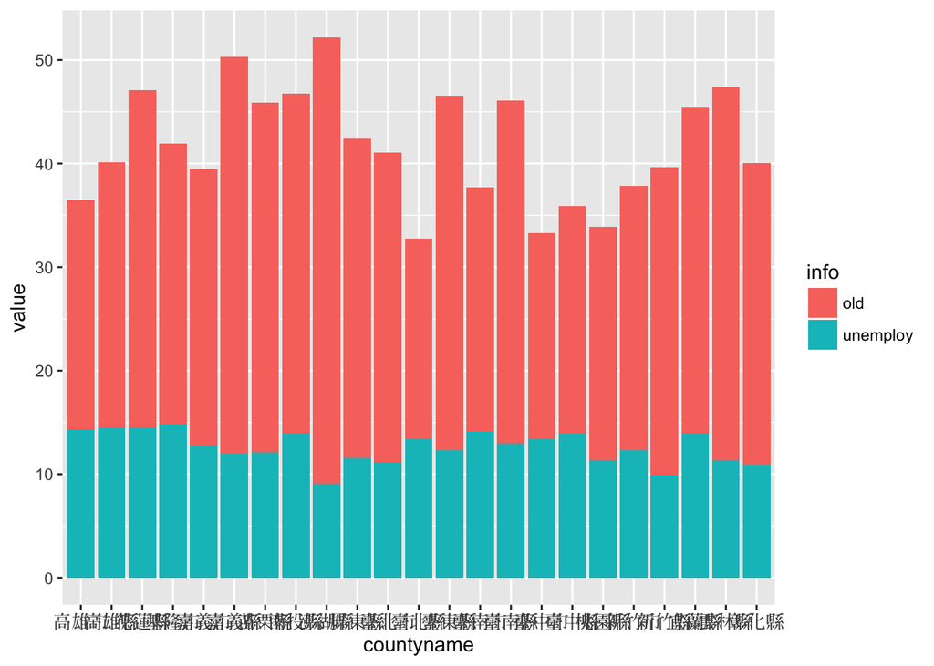

```r
g1<-ggplot(new.df, aes(x=countyname, y=value, fill=info)) +
  geom_bar(stat='identity') +
  theme(axis.text.x=element_text(family="HanWangMingBold", size=10))
g1
```

如果以縣市為單位，而歸納這兩個變數的每一年總和，可以用以下的程式畫圖：

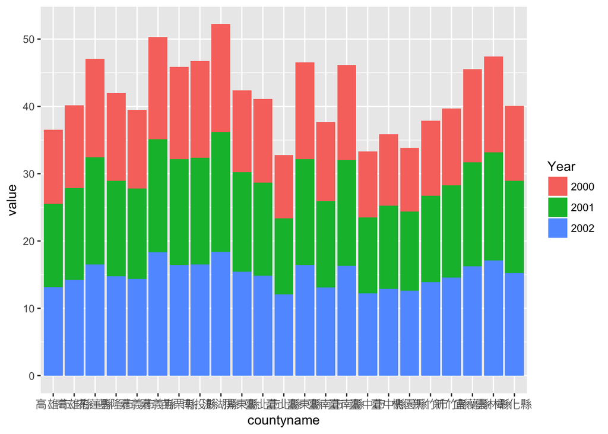

```r
g2<-ggplot(new.df, aes(x=countyname, y=value, fill=Year)) +
  geom_bar(stat='identity') +
  theme(axis.text.x=element_text(family="微軟正黑體", size=10))
g2
```

以上兩種統計方式都是以縣市為單位，而選擇年度（三個類別）或者是統計資料（兩個類別）做為歸納單位，但是有沒有可能同時統計這兩者？也就是每一個縣市、每一個年度、老年人口比率與失業率的數字？

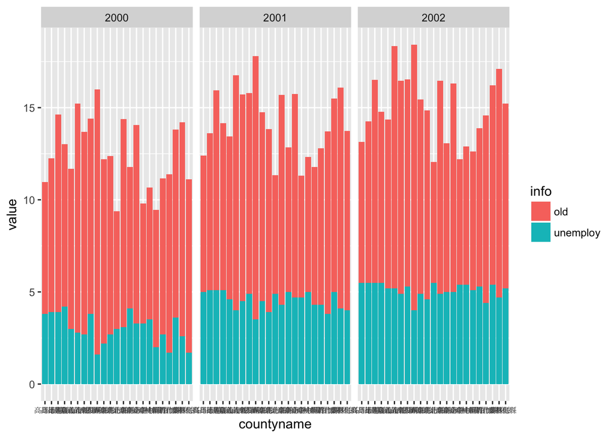

```r
g3<-ggplot(new.df, aes(x=countyname, y=value, fill=info)) +
  geom_bar(stat='identity') +
  facet_wrap( ~ Year) +
  theme(axis.text.x=element_text(family="HanWangMingBold", size=6))
g3
```

以上程式使用facet_wrap()納入第二個類別變數，繪出三個直方圖，分別代表三個年度的兩個變數的比率。  
以上說明寬表、長表的用途，希望能有助於資料轉置以及後續分析。

# 6 作業

- 1. 請下載`nycflights13`這個套件，然後分析`flights`這筆資料，並且建立新變數「速度」，公式為距離(distance)除以飛行時間(air_time)乘以60。請問平均速度多少？最高速多少？可以用`filter`篩選沒有遺漏值的觀察值，例如：

```r
tibble1<-tibble(A=c(NA, NA, NA, 100, 200, 600, NA, 100, 0, 200),
                B=200,
                C=c(rep(300, 5), rep(400, 5)))
tibble1 = filter(tibble1, !is.na(A))
       summarize(tibble1, sum(A,B,C), mean(C))
```

```
## # A tibble: 1 x 2
##   `sum(A, B, C)` `mean(C)`
##            <dbl>     <dbl>
## 1          4600.      367.
```

- 2. 請讀取studentsfull.txt這個檔案，然後計算不同科系同學的平均分數，再根據平均分數排序資料表：
- 3. 請統計`mtcars`這筆資料中cyl的各類的平均馬力(hp) 以及每加侖可以行駛的英里數(mpg)：
- 4. 請統計flights資料中每年的最後一天的平均出發以及抵達的遲到分鐘
- 5. 請從bank.info資料挑出other_cl_bal大於100億的銀行資料，並且列出銀行的名稱。